# Exploration of Deville Cadillacs

## Background

In the fast paced world of vehicles there are many stunning characteristics that can be observed. A data set was taken displaying many features of vehicle brands. Specifically, the point of interest for this analysis is Cadillacs. 30 observations from this data set contains many features, notably: price, milage, trim, and sound of the Deville Cadillacs.

Linked is the data set for the Deville Cadillacs.

Data set of Deville Cadillacs (click to view)

### Exploration Question

In the graph below, the plot displays the Deville model. It is of importance to note the gap in between the two lines. There must be different trends in the Deville model. What accounts for the two different trends?

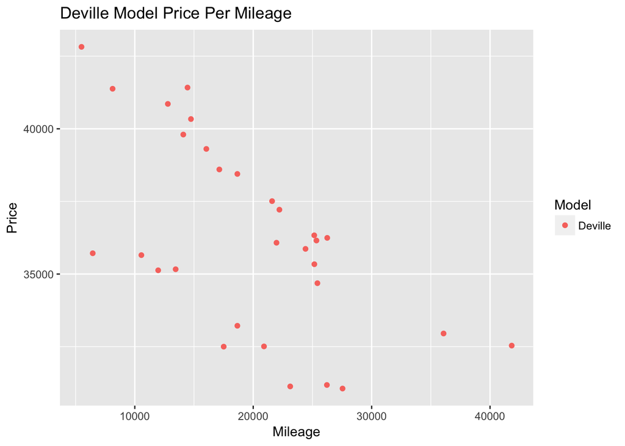

```r
##plot(Price ~ Mileage, data=DCPrices)

DCPrices.lm <- lm(Price ~ Mileage, data=DCPrices)

ggplot(data = DCPrices, aes(x=Mileage, y=Price)) + geom_point()  + aes(colour=Model) + theme(legend.position="right") + labs(title="Deville Model Price Per Mileage")
```

### Baseline Requirements

Linear Relation: the regression relation between Y and X is linear.

Constant Variance: the variance of the error terms is constant over all X values.

Normal Errors: the error terms are normally distributed with a mean of zero.

Independent Errors: the error terms are independent.

Fixed X: the X values can be considered fixed and measured without error. (Assumed to be measured without error)

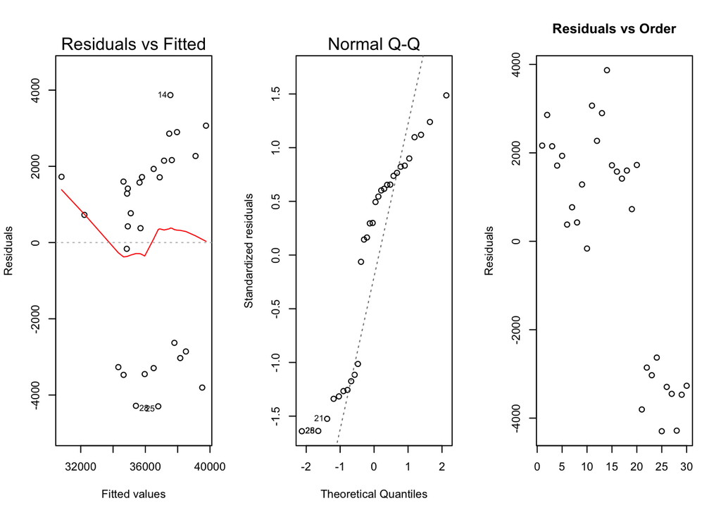

```r
par(mfrow=c(1,3))
plot(DCPrices.lm, which=1:2)
plot(DCPrices.lm$residuals, main="Residuals vs Order", xlab="",
     ylab="Residuals")
```

### Baseline Analysis

The significance level is
$$\alpha = 0.05$$

```r
DCPrices.lm <- lm(Price ~ Mileage, data=DCPrices)
pander(summary(DCPrices.lm))
```

|  | Estimate | Std. Error | t value | Pr(>\|t\|) |
| --- | --- | --- | --- | --- |
| **(Intercept)** | 41106 | 1295 | 31.73 | 1.706e-23 |
| **Mileage** | -0.2461 | 0.0607 | -4.055 | 0.0003624 |

Fitting linear model: Price ~ Mileage

| Observations | Residual Std. Error | $R^2$ | Adjusted $R^2$ |
| --- | --- | --- | --- |
| 30 | 2667 | 0.37 | 0.3475 |

## Sound

A multiple linear regression test was run because the baseline was comparing price and mileage but now adding sound to the test.

### Analysis

The slope of mileage compared to sound is 0.1522 and the y-intercept is 42564. The p-value varifies the slope is the same.

The significance level is
$$\alpha = 0.05$$

```r
DCPrices.lm <- lm(Price ~ Mileage*Sound, data=DCPrices)
pander(summary(DCPrices.lm))
```

|  | Estimate | Std. Error | t value | Pr(>\|t\|) |
| --- | --- | --- | --- | --- |
| **(Intercept)** | 42564 | 1649 | 25.81 | 4.679e-20 |
| **Mileage** | -0.3029 | 0.08196 | -3.696 | 0.001028 |
| **Sound** | -4309 | 2690 | -1.602 | 0.1213 |
| **Mileage:Sound** | 0.1522 | 0.1218 | 1.25 | 0.2225 |

Fitting linear model: Price ~ Mileage * Sound

| Observations | Residual Std. Error | $R^2$ | Adjusted $R^2$ |
| --- | --- | --- | --- |
| 30 | 2624 | 0.4337 | 0.3683 |

### Diagnostical Reports

Requirements for the graph include a few reports.

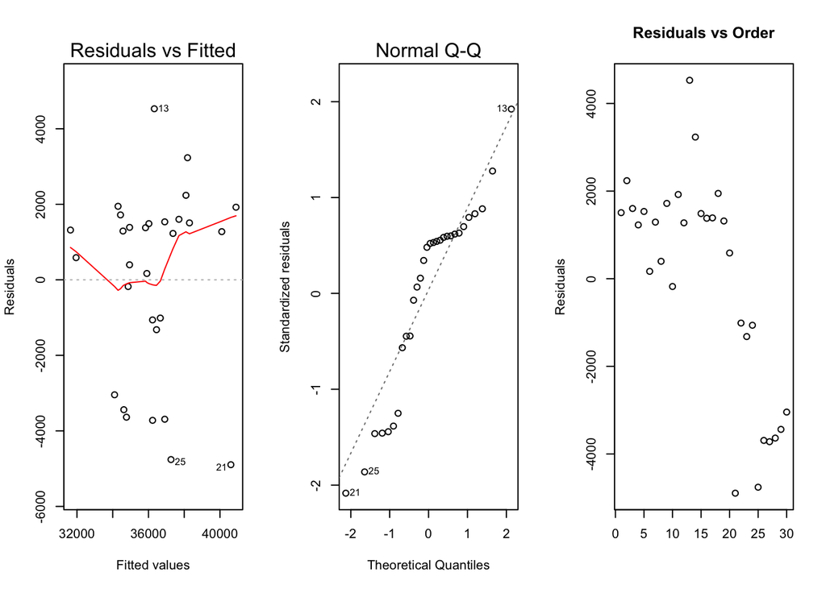

```r
par(mfrow=c(1,3))
plot(DCPrices.lm, which=1:2)
plot(DCPrices.lm$residuals, main="Residuals vs Order", xlab="",
     ylab="Residuals")
```

### Graphical Summary

[figure not shown]

```r
ggplot(data = DCPrices, aes(x=Mileage, y=Price)) + geom_point()  + aes(colour=Sound)  + stat_smooth(method=lm) + theme(legend.position="right") + labs(title="Focus of Trim & Price Per Mileage")
```

As proven in the analysis and graphical summary, sound is not the cause in the different trends of the Deville model. The line of best fit travels through almost the middle of the two distinct trends, which infers sound does not account for the two different trends.

## Trim

This analysis is based on comparing the price and mileage focusing on trim.

### Analysis

```r
DCPrices.lm <- lm(Price ~ Mileage+Trim, data=DCPrices)
pander(summary(DCPrices.lm))
```

|  | Estimate | Std. Error | t value | Pr(>\|t\|) |
| --- | --- | --- | --- | --- |
| **(Intercept)** | 43708 | 387.4 | 112.8 | 1.628e-36 |
| **Mileage** | -0.3077 | 0.01585 | -19.42 | 5.347e-17 |
| **TrimDTS Sedan 4D** | 803.9 | 305.8 | 2.628 | 0.01421 |
| **TrimSedan 4D** | -4953 | 308.2 | -16.07 | 5.096e-15 |

Fitting linear model: Price ~ Mileage + Trim

| Observations | Residual Std. Error | $R^2$ | Adjusted $R^2$ |
| --- | --- | --- | --- |
| 30 | 682.8 | 0.9617 | 0.9572 |

### Diagnostical Reports

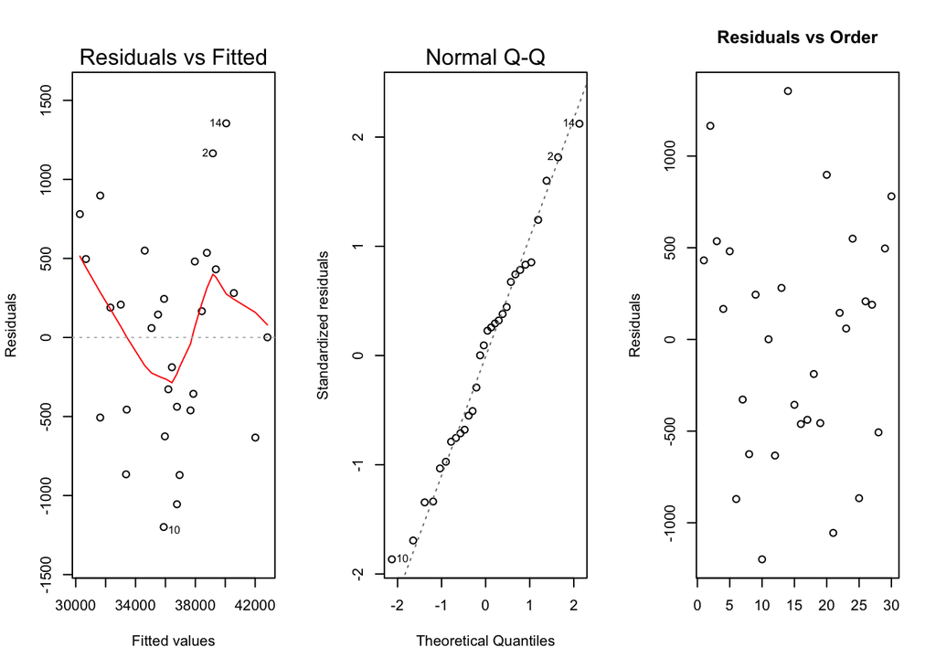

```r
par(mfrow=c(1,3))
plot(DCPrices.lm, which=1:2)
plot(DCPrices.lm$residuals, main="Residuals vs Order", xlab="",
     ylab="Residuals")
```

### Graphical Summary

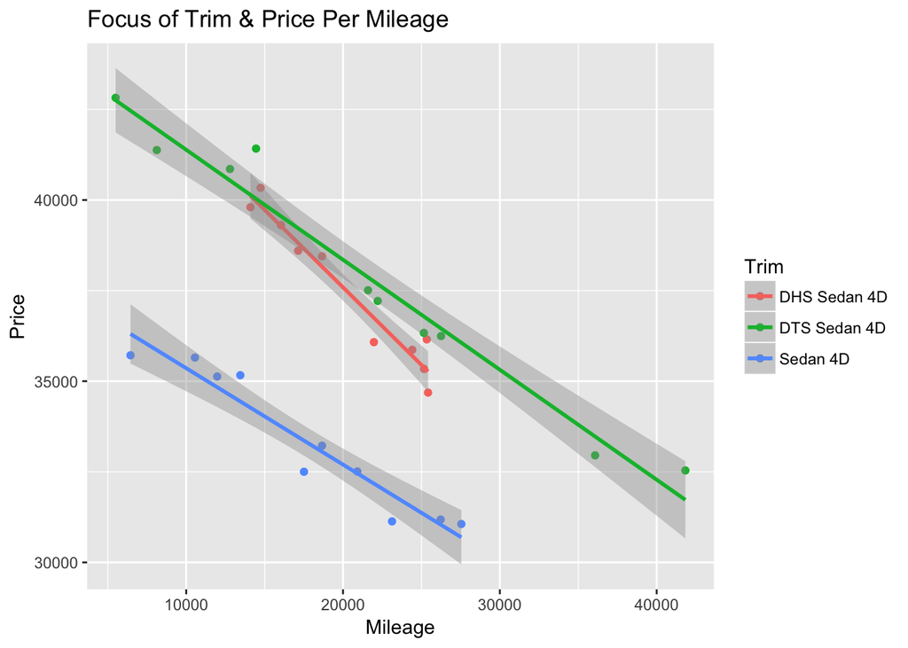

```r
ggplot(data = DCPrices, aes(x=Mileage, y=Price)) + geom_point()  + aes(colour=Trim)  + stat_smooth(method=lm) + theme(legend.position="right") + labs(title="Focus of Trim & Price Per Mileage")
```

## Interpretation

It seems sound does not effect the distinction of the two lines, but the Trim type could affect the distinction. The graph shows the two trim types, DHS Sedan 4D and the DTS Sedan 4D, as one trend type. It would be valuable to run a test to see if the two different trim types were the same.

## Possible Exploration

As noted in the interpretation, a hypothesis test could be run to determine if there was a difference, and more importantly if DHS Sedan 4D and DTS Sedan 4D could be merged as the same trend line, in comparrison to the Sedan 4D.

The null and alternative hypothesis would be stated as
$$H_0: \beta_0 = \beta_1 = \cdots = \beta_p = 0$$
There is no difference in any of the trims for Deville.
$$H_a: \beta_j \neq 0 \ \text{for at least one}\ j \in \{0,1,\ldots,p\}$$
At least one of the trims is different for Deville.

Further analysis according to this hypotheses test would help us to pinpoint the real difference between the two trends in the Deville Cadillacs.